# Exploring Chicago Crime Data

# Lesson Goals

A SparkSession can be used create DataFrame, register DataFrame as tables, execute SQL over tables, cache tables, and read parquet files. It is the entry point to programming Spark with the DataFrame API. We can create a SparkSession, usfollowing builder pattern:

# Prerequests

1. install Apache Spark
2. Install Anaconda
3. Install SpaCy Library
4. Install WordCloud Library

   NB:make sure Jupyter Notebook and Spark running

```python
from pyspark.sql import SparkSession
spark = SparkSession.builder.appName("Chicago_crime_analysis").getOrCreate()
```

```python
# Pre-define Schema for fast reading.
from pyspark.sql.types import  (StructType,
                                StructField,
                                DateType,
                                BooleanType,
                                DoubleType,
                                IntegerType,
                                StringType,
                               TimestampType)


crimes_schema = StructType([StructField("ID", StringType(), True),
                            StructField("CaseNumber", StringType(), True),
                            StructField("Date", StringType(), True ),
                            StructField("Block", StringType(), True),
                            StructField("IUCR", StringType(), True),
                            StructField("PrimaryType", StringType(), True  ),
                            StructField("Description", StringType(), True ),
                            StructField("LocationDescription", StringType(), True ),
                            StructField("Arrest", BooleanType(), True),
                            StructField("Domestic", BooleanType(), True),
                            StructField("Beat", StringType(), True),
                            StructField("District", StringType(), True),
                            StructField("Ward", StringType(), True),
                            StructField("CommunityArea", StringType(), True),
                            StructField("FBICode", StringType(), True ),
                            StructField("XCoordinate", DoubleType(), True),
                            StructField("YCoordinate", DoubleType(), True ),
                            StructField("Year", IntegerType(), True),
                            StructField("UpdatedOn", DateType(), True ),
                            StructField("Latitude", DoubleType(), True),
                            StructField("Longitude", DoubleType(), True),
                            StructField("Location", StringType(), True )
                            ])
```

```python
# Create crimes dataframe using the above defined schema
crimes = spark.read.csv("Crimes_-_2001_to_Present.csv",
                       header = True,
                        schema = crimes_schema)
```

```python
# Display number of rows in the crimes dataframe
print(" The crimes dataframe has {} records".format(crimes.count()))
```

```
 The crimes dataframe has 7161374 records
```

```python
# Display the nature of your column
crimes.columns
```

```
['ID',
 'CaseNumber',
 'Date',
 'Block',
 'IUCR',
 'PrimaryType',
 'Description',
 'LocationDescription',
 'Arrest',
 'Domestic',
 'Beat',
 'District',
 'Ward',
 'CommunityArea',
 'FBICode',
 'XCoordinate',
 'YCoordinate',
 'Year',
 'UpdatedOn',
 'Latitude',
 'Longitude',
 'Location']
```

```python
crimes.dtypes
```

```
[('ID', 'string'),
 ('CaseNumber', 'string'),
 ('Date', 'string'),
 ('Block', 'string'),
 ('IUCR', 'string'),
 ('PrimaryType', 'string'),
 ('Description', 'string'),
 ('LocationDescription', 'string'),
 ('Arrest', 'boolean'),
 ('Domestic', 'boolean'),
 ('Beat', 'string'),
 ('District', 'string'),
 ('Ward', 'string'),
 ('CommunityArea', 'string'),
 ('FBICode', 'string'),
 ('XCoordinate', 'double'),
 ('YCoordinate', 'double'),
 ('Year', 'int'),
 ('UpdatedOn', 'date'),
 ('Latitude', 'double'),
 ('Longitude', 'double'),
 ('Location', 'string')]
```

```python
crimes.printSchema()
```

```
root
 |-- ID: string (nullable = true)
 |-- CaseNumber: string (nullable = true)
 |-- Date: string (nullable = true)
 |-- Block: string (nullable = true)
 |-- IUCR: string (nullable = true)
 |-- PrimaryType: string (nullable = true)
 |-- Description: string (nullable = true)
 |-- LocationDescription: string (nullable = true)
 |-- Arrest: boolean (nullable = true)
 |-- Domestic: boolean (nullable = true)
 |-- Beat: string (nullable = true)
 |-- District: string (nullable = true)
 |-- Ward: string (nullable = true)
 |-- CommunityArea: string (nullable = true)
 |-- FBICode: string (nullable = true)
 |-- XCoordinate: double (nullable = true)
 |-- YCoordinate: double (nullable = true)
 |-- Year: integer (nullable = true)
 |-- UpdatedOn: date (nullable = true)
 |-- Latitude: double (nullable = true)
 |-- Longitude: double (nullable = true)
 |-- Location: string (nullable = true)
```

```python
# Apply select. show function to see few rows
crimes.select("Date").show(10, truncate = False)
```

```
+----------------------+
|Date                  |
+----------------------+
|01/01/2001 11:00:00 AM|
|10/08/2017 03:00:00 AM|
|03/28/2017 02:00:00 PM|
|09/09/2017 08:17:00 PM|
|08/26/2017 10:00:00 AM|
|02/10/2013 12:00:00 AM|
|01/01/2015 12:01:00 AM|
|01/01/2017 12:01:00 AM|
|07/17/2017 10:10:00 AM|
|12/28/2017 03:55:00 PM|
+----------------------+
only showing top 10 rows
```

```python
# Change Date column datatype with User Define Function(UDF)
# Create new column using WithColumn function and drop the old column with drop function

from datetime import datetime
from pyspark.sql.functions import col,udf

myfunc =  udf(lambda x: datetime.strptime(x, '%m/%d/%Y %I:%M:%S %p'), TimestampType())
df = crimes.withColumn('Date_time', myfunc(col('Date'))).drop("Date")

df.select(df["Date_time"]).show(5)
```

```
+-------------------+
|          Date_time|
+-------------------+
|2001-01-01 11:00:00|
|2017-10-08 03:00:00|
|2017-03-28 14:00:00|
|2017-09-09 20:17:00|
|2017-08-26 10:00:00|
+-------------------+
only showing top 5 rows
```

```python
# Perform Descriptive Statistic on String and numeric column
# Apply Python list technique to select multiple column

crimes.select(["Latitude","Longitude","Year","XCoordinate","YCoordinate"]).describe().show()
```

```
+-------+-------------------+-------------------+------------------+------------------+------------------+
|summary|           Latitude|          Longitude|              Year|       XCoordinate|       YCoordinate|
+-------+-------------------+-------------------+------------------+------------------+------------------+
|  count|            7092124|            7092124|           7161374|           7092124|           7092124|
|   mean|  41.84202603398476| -87.67169754382614|2008.9455657531641|1164545.3123478945|1885725.1762411373|
| stddev|0.08984528568967894|0.06199228302144005|5.4815074054086175|17126.958947364754|32651.055235361644|
|    min|       36.619446395|      -91.686565684|              2001|               0.0|               0.0|
|    max|       42.022910333|      -87.524529378|              2020|         1205119.0|         1951622.0|
+-------+-------------------+-------------------+------------------+------------------+------------------+
```

```python
# Oops! the table looks ugly. Apply format_number PySpark functions to get ride of it

from pyspark.sql.functions import format_number

result = crimes.select(["Latitude","Longitude","Year","XCoordinate","YCoordinate"]).describe()
result.select(result['summary'],
              format_number(result['Latitude'].cast('float'),2).alias('Latitude'),
              format_number(result['Longitude'].cast('float'),2).alias('Longitude'),
              result['Year'].cast('int').alias('year'),
              format_number(result['XCoordinate'].cast('float'),2).alias('XCoordinate'),
              format_number(result['YCoordinate'].cast('float'),2).alias('YCoordinate')
             ).show()
```

```
+-------+------------+------------+-------+------------+------------+
|summary|    Latitude|   Longitude|   year| XCoordinate| YCoordinate|
+-------+------------+------------+-------+------------+------------+
|  count|7,092,124.00|7,092,124.00|7161374|7,092,124.00|7,092,124.00|
|   mean|       41.84|      -87.67|   2008|1,164,545.25|1,885,725.12|
| stddev|        0.09|        0.06|      5|   17,126.96|   32,651.05|
|    min|       36.62|      -91.69|   2001|        0.00|        0.00|
|    max|       42.02|      -87.52|   2020|1,205,119.00|1,951,622.00|
+-------+------------+------------+-------+------------+------------+
```

```python
# Apply distinct function to know about the number of primary crime type

crimes.select("PrimaryType").distinct().count()
```

```
36
```

```python
# Apply Show function to see the list of Primary crime type

crimes.select("PrimaryType").distinct().show(n = 35)
```

```
+--------------------+
|         PrimaryType|
+--------------------+
|OFFENSE INVOLVING...|
|CRIMINAL SEXUAL A...|
|            STALKING|
|PUBLIC PEACE VIOL...|
|           OBSCENITY|
|NON-CRIMINAL (SUB...|
|               ARSON|
|   DOMESTIC VIOLENCE|
|            GAMBLING|
|   CRIMINAL TRESPASS|
|             ASSAULT|
|      NON - CRIMINAL|
|LIQUOR LAW VIOLATION|
| MOTOR VEHICLE THEFT|
|               THEFT|
|             BATTERY|
|             ROBBERY|
|            HOMICIDE|
|           RITUALISM|
|    PUBLIC INDECENCY|
| CRIM SEXUAL ASSAULT|
|   HUMAN TRAFFICKING|
|        INTIMIDATION|
|        PROSTITUTION|
|  DECEPTIVE PRACTICE|
|CONCEALED CARRY L...|
|         SEX OFFENSE|
|     CRIMINAL DAMAGE|
|           NARCOTICS|
|        NON-CRIMINAL|
|       OTHER OFFENSE|
|          KIDNAPPING|
|            BURGLARY|
|   WEAPONS VIOLATION|
|OTHER NARCOTIC VI...|
+--------------------+
only showing top 35 rows
```

```python
# Show number of  HOMICIDE
crimes.where(crimes["PrimaryType"] == "HOMICIDE").count()
```

```
10479
```

```python
# Show number of  Domestic assault

crimes.filter((crimes["PrimaryType"] == "ASSAULT") & (crimes["Domestic"] == "True")).count()
```

```
100238
```

```python
# Use Filter or where function to show selected column

columns = ['PrimaryType', 'Description', 'Arrest', 'Domestic']

crimes.where((crimes["PrimaryType"] == "HOMICIDE") & (crimes["Arrest"] == "true"))\
                                                        .select(columns).show(10)
```

```
+-----------+-------------------+------+--------+
|PrimaryType|        Description|Arrest|Domestic|
+-----------+-------------------+------+--------+
|   HOMICIDE|FIRST DEGREE MURDER|  true|    true|
|   HOMICIDE|FIRST DEGREE MURDER|  true|   false|
|   HOMICIDE|FIRST DEGREE MURDER|  true|   false|
|   HOMICIDE|FIRST DEGREE MURDER|  true|   false|
|   HOMICIDE|FIRST DEGREE MURDER|  true|   false|
|   HOMICIDE|FIRST DEGREE MURDER|  true|   false|
|   HOMICIDE|FIRST DEGREE MURDER|  true|   false|
|   HOMICIDE|FIRST DEGREE MURDER|  true|    true|
|   HOMICIDE|FIRST DEGREE MURDER|  true|   false|
|   HOMICIDE|FIRST DEGREE MURDER|  true|   false|
+-----------+-------------------+------+--------+
only showing top 10 rows
```

```python
# Apply Limit function to show selected column in the dataframe

crimes.select(columns).limit(10). show(truncate = True)
```

```
+--------------------+--------------------+------+--------+
|         PrimaryType|         Description|Arrest|Domestic|
+--------------------+--------------------+------+--------+
|  DECEPTIVE PRACTICE|FINANCIAL IDENTIT...| false|   false|
| CRIM SEXUAL ASSAULT|      NON-AGGRAVATED| false|   false|
|            BURGLARY|      UNLAWFUL ENTRY| false|   false|
|               THEFT|           OVER $500| false|   false|
| CRIM SEXUAL ASSAULT|      NON-AGGRAVATED| false|   false|
| CRIM SEXUAL ASSAULT|           PREDATORY| false|   false|
|OFFENSE INVOLVING...|CRIM SEX ABUSE BY...| false|    true|
|OFFENSE INVOLVING...|AGG SEX ASSLT OF ...| false|   false|
|               THEFT|           OVER $500| false|   false|
|  DECEPTIVE PRACTICE|FINANCIAL IDENTIT...| false|   false|
+--------------------+--------------------+------+--------+
```

```python
# Create New Column using withColumn function

lat_max = crimes.agg({"Latitude" : "max"}).collect()[0][0]

print("The maximum latitude values is {}".format(lat_max))
```

```
The maximum latitude values is 42.022910333
```

```python
df = crimes.withColumn("difference_from_max_lat",lat_max - crimes["Latitude"])
```

```python
# Rename Latitude to Lat
df = crimes.withColumnRenamed("Latitude", "Lat")
df.columns
```

```
['ID',
 'CaseNumber',
 'Date',
 'Block',
 'IUCR',
 'PrimaryType',
 'Description',
 'LocationDescription',
 'Arrest',
 'Domestic',
 'Beat',
 'District',
 'Ward',
 'CommunityArea',
 'FBICode',
 'XCoordinate',
 'YCoordinate',
 'Year',
 'UpdatedOn',
 'Lat',
 'Longitude',
 'Location']
```

```python
columns = ['PrimaryType', 'Description', 'Arrest', 'Domestic','Lat']

df.orderBy(df["Lat"].desc()).select(columns).show(10)
```

```
+-------------------+--------------------+------+--------+------------+
|        PrimaryType|         Description|Arrest|Domestic|         Lat|
+-------------------+--------------------+------+--------+------------+
|              THEFT|      $500 AND UNDER| false|   false|42.022910333|
|MOTOR VEHICLE THEFT|          AUTOMOBILE| false|   false|42.022878225|
|           BURGLARY|      UNLAWFUL ENTRY| false|   false|42.022709624|
|    CRIMINAL DAMAGE|         TO PROPERTY| false|   false|42.022671246|
|              THEFT|      $500 AND UNDER| false|   false|42.022671246|
|              THEFT|      POCKET-PICKING| false|   false|42.022671246|
|      OTHER OFFENSE|    PAROLE VIOLATION|  true|   false|42.022671246|
|    CRIMINAL DAMAGE|          TO VEHICLE| false|   false|42.022653914|
|          NARCOTICS|POSS: CANNABIS 30...|  true|   false|42.022644813|
|            BATTERY|              SIMPLE| false|    true|42.022644813|
+-------------------+--------------------+------+--------+------------+
only showing top 10 rows
```

```python
# Let us apply some Statistic to our dataframe
from pyspark.sql.functions import mean
df.select(mean("Lat")).alias("Mean Latitude").show()
```

```
+-----------------+
|         avg(Lat)|
+-----------------+
|41.84202603398476|
+-----------------+
```

```python
# Apply agg function to show average

df.agg({"Lat":"avg"}).show()
```

```
+-----------------+
|         avg(Lat)|
+-----------------+
|41.84202603398476|
+-----------------+
```

```python
# # Let us apply some Statistic to our dataframe

from pyspark.sql.functions import max,min
df.select(max("Xcoordinate"),min("Xcoordinate")).show()
```

```
+----------------+----------------+
|max(Xcoordinate)|min(Xcoordinate)|
+----------------+----------------+
|       1205119.0|             0.0|
+----------------+----------------+
```

```python
# Apply filter function to know the percentage of Domestic crime

df.filter(df["Domestic"]==True).count()/df.count() * 100
```

```
13.359615068281588
```

```python
# Apply correlation function to know the relationship of the column in the dataframe

from pyspark.sql.functions import corr
df.select(corr("Lat","Ycoordinate")).show()
```

```
+----------------------+
|corr(Lat, Ycoordinate)|
+----------------------+
|    0.9999933947744902|
+----------------------+
```

```python
# Apply groupby function to know the number of crime per year

df.groupBy("Year").count().show()
```

```
+----+------+
|Year| count|
+----+------+
|2003|475959|
|2007|437038|
|2018|268083|
|2015|264422|
|2006|448135|
|2013|307269|
|2014|275517|
|2019|259570|
|2004|469394|
|2020|113474|
|2012|336122|
|2009|392762|
|2016|269379|
|2001|485779|
|2005|453731|
|2010|370393|
|2011|351870|
|2008|427095|
|2017|268620|
|2002|486762|
+----+------+
```

```python
df.groupBy("Year").count().collect()
```

```
[Row(Year=2003, count=475959),
 Row(Year=2007, count=437038),
 Row(Year=2018, count=268083),
 Row(Year=2015, count=264422),
 Row(Year=2006, count=448135),
 Row(Year=2013, count=307269),
 Row(Year=2014, count=275517),
 Row(Year=2019, count=259570),
 Row(Year=2004, count=469394),
 Row(Year=2020, count=113474),
 Row(Year=2012, count=336122),
 Row(Year=2009, count=392762),
 Row(Year=2016, count=269379),
 Row(Year=2001, count=485779),
 Row(Year=2005, count=453731),
 Row(Year=2010, count=370393),
 Row(Year=2011, count=351870),
 Row(Year=2008, count=427095),
 Row(Year=2017, count=268620),
 Row(Year=2002, count=486762)]
```

```python
# Visualize the number of crime per year using matplotlib and pandas

count = [item[1] for item in df.groupBy("Year").count().collect()]
year = [item[0] for item in df.groupBy("Year").count().collect()]
```

```python
number_of_crimes_per_year = {"count":count, "year" : year}
```

```python
import pandas as pd
import matplotlib.pyplot as plt
%matplotlib inline
```

```python
number_of_crimes_per_year = pd.DataFrame(number_of_crimes_per_year)
```

```python
number_of_crimes_per_year.head()
```

|  | count | year |
| --- | --- | --- |
| 0 | 475959 | 2003 |
| 1 | 437038 | 2007 |
| 2 | 268083 | 2018 |
| 3 | 264422 | 2015 |
| 4 | 448135 | 2006 |

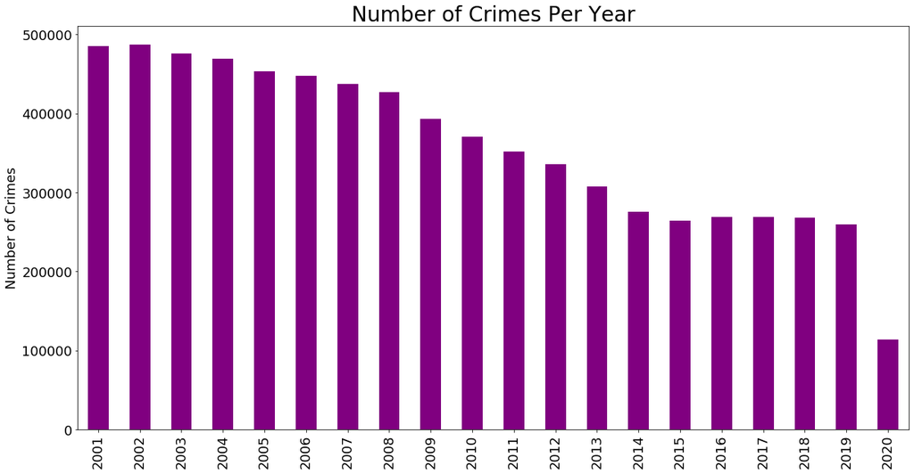

```python
number_of_crimes_per_year = number_of_crimes_per_year.sort_values(by = "year")

number_of_crimes_per_year.plot(figsize = (20,10), kind = "bar", color = "purple",
                               x = "year", y = "count", legend = False)

plt.xlabel("", fontsize = 18)
plt.ylabel("Number of Crimes", fontsize = 18)
plt.title("Number of Crimes Per Year", fontsize = 28)
plt.xticks(size = 18)
plt.yticks(size = 18)
plt.show()
```

```python
from pyspark.sql.functions import month
monthdf = df.withColumn("Month",month(df["Date_time"]))
monthCounts = monthdf.select("Month").groupBy("Month").count()
monthCounts.show()
```

[output not shown]

```python
crimes.groupBy("LocationDescription").count().show()
```

```
+--------------------+------+
| LocationDescription| count|
+--------------------+------+
|   RAILROAD PROPERTY|    14|
|SCHOOL - PRIVATE ...|    24|
|AIRPORT TERMINAL ...|  1822|
|VEHICLE - COMMERCIAL|    53|
|EXPRESSWAY EMBANK...|     1|
|POLICE FACILITY/V...| 18588|
|RESIDENCE - YARD ...|  1620|
|               MOTEL|     6|
|CHA PARKING LOT /...|   200|
|            SIDEWALK|695494|
|AIRPORT TERMINAL ...|    92|
|PUBLIC GRAMMAR SC...|     1|
|OTHER RAILROAD PR...|    49|
|CTA GARAGE / OTHE...| 10281|
|            CAR WASH|  2961|
|   TRUCKING TERMINAL|     1|
|    AIRPORT/AIRCRAFT| 16135|
|            HOSPITAL|    10|
|MEDICAL/DENTAL OF...|  7437|
|    FEDERAL BUILDING|   846|
+--------------------+------+
only showing top 20 rows
```

```python
crime_location  = crimes.groupBy("LocationDescription").count().collect()
location = [item[0] for item in crime_location]
count = [item[1] for item in crime_location]
crime_location = {"location" : location, "count": count}
crime_location = pd.DataFrame(crime_location)
crime_location = crime_location.sort_values(by = "count", ascending  = False)
crime_location.iloc[:5]
```

|  | location | count |
| --- | --- | --- |
| 72 | STREET | 1861059 |
| 121 | RESIDENCE | 1213272 |
| 154 | APARTMENT | 756950 |
| 9 | SIDEWALK | 695494 |
| 155 | OTHER | 270209 |

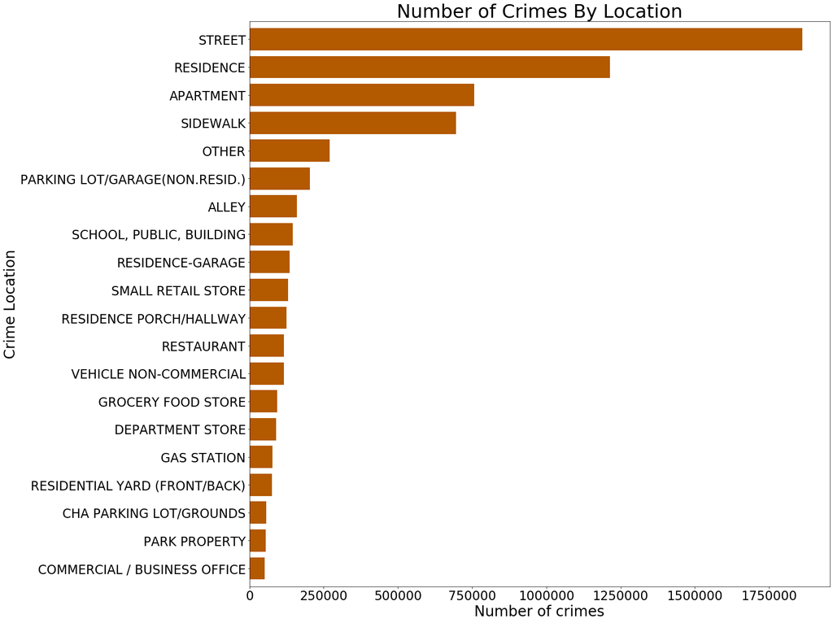

```python
crime_location = crime_location.iloc[:20]

myplot = crime_location .plot(figsize = (20,20), kind = "barh", color = "#b35900", width = 0.8,
                               x = "location", y = "count", legend = False)

myplot.invert_yaxis()

plt.xlabel("Number of crimes", fontsize = 28)
plt.ylabel("Crime Location", fontsize = 28)
plt.title("Number of Crimes By Location", fontsize = 36)
plt.xticks(size = 24)
plt.yticks(size = 24)
plt.show()
```

```python
from pyspark.sql.functions import date_format
df = df.withColumn("DayOfWeek", date_format("Date_time","E")).\
      withColumn("DayOfWeek_number", date_format("Date_time","u")).\
      withColumn("HourOfDay", date_format("Date_time","H"))
weekDaysCount  = df.groupBy(["DayOfWeek", "DayOfWeek_number"]).count()
weekDaysCount.show()
```

[output not shown]

# Further reading

1.Apache Spark [link](http://spark.apache.org/examples.html/).

2.Exploring Big Data Analysis: Fundamental Scientific Problems [link](https://link.springer.com/article/10.1007/s40745-015-0063-7).

3.Hadoop with Python by Zach Radtka, Donald Miner [link](https://www.oreilly.com/library/view/hadoop-with-python/9781492048435/ch04.html)

# Summary

Specifically, you learned:

1.How to create schema and dataframe 2.How to visualized your data using the Spark SQL module 3.Change Date column datatype with User Define Function(UDF) 4.How to calculate summary statistics 5.How to visualised the crime data using Pandas and matplotlib library from Python API

You also Answered the following question from the Chicago crime datase out:

What are the primary crime type in Chicago? What are the percentage of domestic crime in Chicago? Which year are the most crime year?